# FTH 2026 Soil Macrofauna statistical analysis

Authors

Jason Berger

Nina Farah

Juliette Kiffer

Nelle Konczak

```r
### Utilities for R.

# Necessary packages
packages_required <- c(
  "knitr", "tidyverse", "vegan", "permute",
  "ggrepel", "grid", "dplyr", "readxl", "glmmTMB",
  "DHARMa", "car", "emmeans", "ggnewscale"
)
# Already installed?
packages_installed <- vapply(
  packages_required,
  FUN = requireNamespace,
  FUN.VALUE = TRUE,
  quietly = TRUE
)
# Install missing packages
install.packages(names(packages_installed)[!packages_installed])

# Chunk font size hook: allows size='small'
# or any valid Latex font size in chunk options
def.chunk.hook <- knitr::knit_hooks$get("chunk")
knitr::knit_hooks$set(
  chunk = function(x, options) {
    x <- def.chunk.hook(x, options)
    ifelse(
      options$size == "normalsize",
      yes = x,
      no = paste0("\n \\", options$size, "\n\n", x, "\n\n \\normalsize")
    )
  }
)

#load all packages
invisible(lapply(packages_required, library, character.only = TRUE))

# Set output width to prevent long model summaries overflowing PDF margins
knitr::opts_chunk$set(width = 65)

#set seed for reproducible simulations throughout the document
set.seed(123)
```

# 1 Preparation

## 1.1 Loading data

```r
df <- read_excel("../data/macrofaune_counts.xlsx")
df<-read_excel("C:/Users/jujuk/OneDrive/Documents/M2 Kourou/PROJET PEDO/FTH_2026_soil_macrofauna/data/macrofaune_counts.xlsx")
df[7:ncol(df)] <- lapply(df[7:ncol(df)], as.numeric)
df[c(1, 3:6)] <- lapply(df[c(1, 3:6)], as.factor)
str(df)
```

```
tibble [60 × 34] (S3: tbl_df/tbl/data.frame)
 $ monolith_ID            : Factor w/ 20 levels "Alt_1_1","Alt_1_2",..: 1 1 1 2 2 2 3 3 3 4 ...
 $ sample_ID              : chr [1:60] "Alt_1_1_L" "Alt_1_1_10" "Alt_1_1_20" "Alt_1_2_L" ...
 $ soil_type              : Factor w/ 2 levels "alt","dls": 1 1 1 1 1 1 1 1 1 1 ...
 $ layer                  : Factor w/ 3 levels "10","20","L": 3 1 2 3 1 2 3 1 2 3 ...
 $ date                   : Factor w/ 4 levels "15.09.2026","16.09.2026",..: 1 1 1 1 1 1 1 1 1 1 ...
 $ identification         : Factor w/ 2 levels "Jason","Raphael": 1 1 1 1 1 1 1 1 1 1 ...
 $ Acarina                : num [1:60] 1 0 0 0 0 0 2 0 0 0 ...
 $ Araneae                : num [1:60] 0 0 0 0 0 0 1 0 0 0 ...
 $ Auchenorrhyncha        : num [1:60] 0 0 0 0 0 0 0 0 0 0 ...
 $ Blattodea_non_termite  : num [1:60] 0 0 0 0 0 0 0 0 0 0 ...
 $ Chilopoda              : num [1:60] 0 1 0 0 0 0 0 1 1 0 ...
 $ Coleoptera_sum         : num [1:60] 9 1 1 0 2 1 0 0 0 0 ...
 $ Collembola             : num [1:60] 1 0 0 1 0 0 0 1 0 0 ...
 $ Diplopoda              : num [1:60] 0 0 1 0 0 0 0 0 1 0 ...
```

[output cut: 20 more lines]

## 1.2 Setting figure color scheme (colorblind-checked)

```r
# readability verified deuteranopia, protanopia, tritanopia and on greyscale

layer_colors <- c(
  "L"  = "#AFC8B5",
  "10" = "#B47A2C",
  "20" = "#355C7D"
)

soil_colors <- c(
  "alt" = "#C5A36A",
  "dls" = "#394B45"
)

taxon_colors <- c(
  "Formicidae" = "#B56B32",
  "Isoptera" = "#496987",
  "Lumbricina_oligochaetes" = "#527F68",
  "Others" = "#A6A39B"
)
```

# 2 Statistical Analysis

## 2.1 Data preparation for GLMM:

```r
# identify taxa columns
taxa_cols <- names(df)[7:34]

# long-format dataset
df_long <- df %>%
  pivot_longer(
    cols = all_of(taxa_cols),
    names_to = "taxon",
    values_to = "count"
  ) %>%
  mutate(
    taxon = factor(taxon)
  )

# sample-level abundance (per m²)
df_total <- df %>%
  mutate(
    total_count = rowSums(
      across(all_of(taxa_cols)),
      na.rm = FALSE
    ),
    density = total_count * 16, #25x25cm monoliths = 1/16 m²
    soil_type = factor(soil_type),
    layer = factor(layer, levels = c("L", "10", "20")),
    monolith_ID = factor(monolith_ID)
  )
```

## 2.2 Explorative Analysis

### 2.2.1 Key values

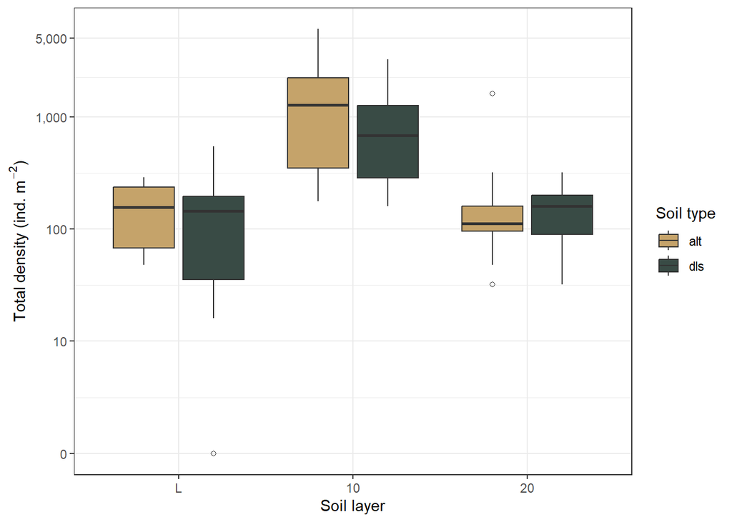

```r
# Boxplot of total macrofauna density
fig_density <- ggplot(
  df_total,
  aes(
    x = layer,
    y = density,
    fill = soil_type
  )
) +
  geom_boxplot(
    width = 0.7,
    position = position_dodge(width = 0.8),
    outlier.shape = 1
  ) +
  scale_fill_manual(values = soil_colors) +
  scale_y_continuous(
  trans = scales::pseudo_log_trans(base = 10),
  breaks = c(0, 10, 100, 1000, 5000),
  labels = scales::label_comma()
) +
  labs(
    x = "Soil layer",
    y = expression("Total density (ind. m"^{-2}*")"),
    fill = "Soil type"
  ) +
  theme_bw()

print(fig_density)
```

The difference of total density between ALT and DSL seems not evident on the graph. The layer 10 seems have higher density that 20 and L bit not difference between 20 and L.

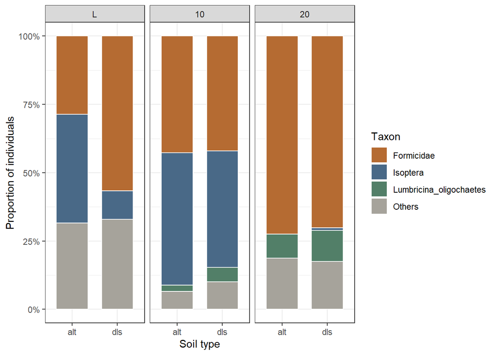

```r
# Convert taxonomic data to long format
df_long <- df %>%
  pivot_longer(
    cols = 7:34,
    names_to = "taxon",
    values_to = "count"
  ) %>%
  mutate(
    taxon = factor(taxon)
  )

# Group taxa into the three focal groups and others
composition <- df_long %>%
  mutate(
    taxon_group = case_when(
      taxon == "Formicidae" ~ "Formicidae",
      taxon == "Isoptera" ~ "Isoptera",
      taxon == "Lumbricina_oligochaetes" ~ "Lumbricina_oligochaetes",
      TRUE ~ "Others"
    ),
    layer = factor(layer, levels = c("L", "10", "20")),
    taxon_group = factor(
      taxon_group,
      levels = names(taxon_colors)
    )
  ) %>%
  group_by(soil_type, layer, taxon_group) %>%
  summarise(
    total = sum(count, na.rm = TRUE),
    .groups = "drop"
  ) %>%
  group_by(soil_type, layer) %>%
  mutate(
    proportion = total / sum(total)
  ) %>%
  ungroup()

# Plot taxonomic composition
fig_composition <- ggplot(
  composition,
  aes(
    x = soil_type,
    y = proportion,
    fill = taxon_group
  )
) +
  geom_col(
    colour = "white",
    width = 0.7
  ) +
  facet_wrap(~ layer) +
  scale_y_continuous(
    labels = scales::percent,
    limits = c(0, 1)
  ) +
  scale_fill_manual(
    values = taxon_colors,
    drop = FALSE
  ) +
  labs(
    x = "Soil type",
    y = "Proportion of individuals",
    fill = "Taxon"
  ) +
  theme_bw()

print(fig_composition)
```

Formicidae, Isoptera and Lumbricina are the most abundant groups in our samples. The other groups have been gathered together because their respective small abundance. The abundances of the tree mains group seems changed between layers : Formicidae are more abundant in the 20 layer but seems dominated in each soil types and layers. Isoptera are nearly absent in the layer 20, but they dominate as Formicidae in the layer 10 and layer L in ALT. Lumbricina are absent in the layer L, and seem more abundant in the layer 20 than 10.

### 2.2.2 PCA

```r
# Community matrix
comm <- as.matrix(df[, taxa_cols])
storage.mode(comm) <- "numeric"

# Remove samples with zero total abundance
keep <- rowSums(comm) > 0 # one removed

comm_pca <- comm[keep, , drop = FALSE]

# Hellinger transformation
comm_hel <- vegan::decostand(comm_pca, method = "hellinger")

# PCA
pca <- prcomp(
  comm_hel,
  center = TRUE,
  scale. = FALSE
)

# Percentage of variance explained
variance_pca <- 100 * pca$sdev^2 / sum(pca$sdev^2)

# Scores and metadata
scores_pca <- as.data.frame(pca$x[, 1:2]) %>%
  mutate(
    soil_type = df$soil_type[keep],
    layer = factor(df$layer[keep], levels = c("L", "10", "20")),
    monolith_ID = df$monolith_ID[keep]
  )

# Taxon coordinates from PCA loadings
taxa_scores <- as.data.frame(pca$rotation[, 1:2]) %>%
  tibble::rownames_to_column("taxon") %>%
  mutate(
    cos2 = PC1^2 + PC2^2
  )

# Scale taxon arrows to fit sample scores
arrow_scale <- min(
  diff(range(scores_pca$PC1)) / diff(range(taxa_scores$PC1)),
  diff(range(scores_pca$PC2)) / diff(range(taxa_scores$PC2))
) * 0.7

taxa_scores <- taxa_scores %>%
  mutate(
    PC1_arrow = PC1 * arrow_scale,
    PC2_arrow = PC2 * arrow_scale
  )

# Keep taxa reasonably represented on the first two PCA axes
taxa_scores_plot <- taxa_scores %>%
  filter(cos2 >= 0.10) # can change cos2 here
```

1 sample has to be removed for PCA due to zero abundance

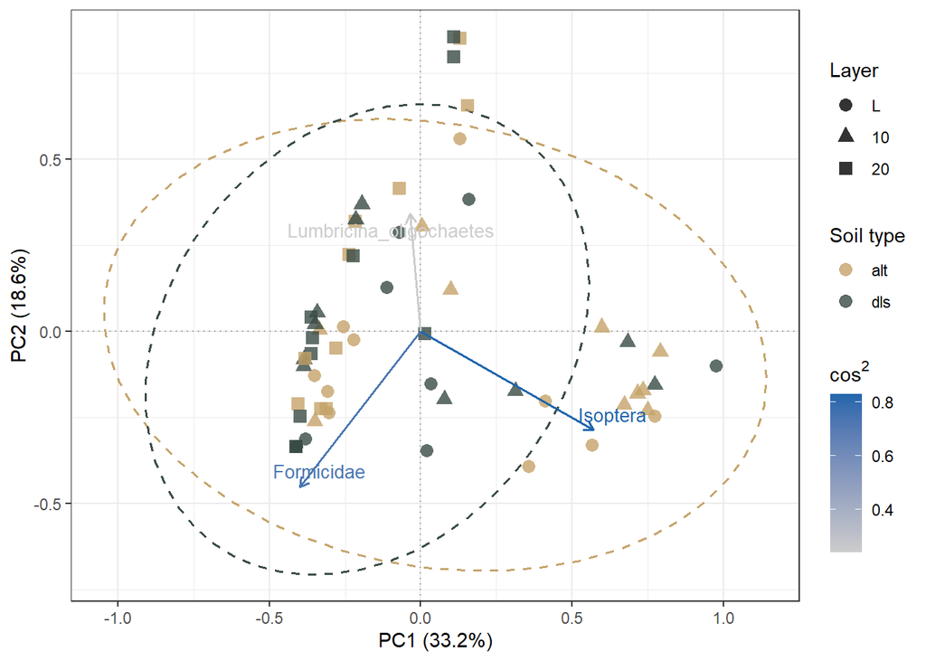

```r
fig_pca <- ggplot(
  scores_pca,
  aes(
    x = PC1,
    y = PC2,
    colour = soil_type,
    shape = layer
  )
) +

  # Reference lines at the origin
  geom_hline(
    yintercept = 0,
    linetype = "dotted",
    colour = "grey65",
    linewidth = 0.4,
    inherit.aes = FALSE
  ) +
  geom_vline(
    xintercept = 0,
    linetype = "dotted",
    colour = "grey65",
    linewidth = 0.4,
    inherit.aes = FALSE
  ) +

  # Confidence ellipses by soil type
 stat_ellipse(
  data = scores_pca,
  mapping = aes(
    x = PC1,
    y = PC2,
    group = soil_type,
    colour = soil_type
  ),
  level = 0.95,
  type = "t",
  linetype = "dashed",
  linewidth = 0.7,
  show.legend = FALSE,
  inherit.aes = FALSE
) +

  # Sample scores
  geom_point(
    size = 3,
    alpha = 0.8
  ) +

  # Discrete colour scale for soil type
  scale_colour_manual(
    values = soil_colors,
    name = "Soil type"
  ) +

  # Start a separate colour scale for taxon arrows
  ggnewscale::new_scale_colour() +

  # Taxon arrows, coloured by cos2
  geom_segment(
    data = taxa_scores_plot,
    aes(
      x = 0,
      y = 0,
      xend = PC1_arrow,
      yend = PC2_arrow,
      colour = cos2
    ),
    inherit.aes = FALSE,
    arrow = grid::arrow(
      length = grid::unit(0.2, "cm")
    ),
    linewidth = 0.6
  ) +

  # Taxon labels, coloured by cos2
  ggrepel::geom_text_repel(
    data = taxa_scores_plot,
    aes(
      x = PC1_arrow,
      y = PC2_arrow,
      label = taxon,
      colour = cos2
    ),
    inherit.aes = FALSE,
    size = 3.5,
    max.overlaps = Inf,
    show.legend = FALSE
  ) +

  # Continuous colour scale for taxon cos2
  scale_colour_gradient(
    low = "grey80",
    high = "#2166AC",
    name = expression(cos^2)
  ) +

  # Layer shapes
  scale_shape_manual(
    values = c(
      "L" = 16,
      "10" = 17,
      "20" = 15
    ),
    name = "Layer"
  ) +

  # Axis labels
  labs(
    x = paste0(
      "PC1 (",
      round(variance_pca[1], 1),
      "%)"
    ),
    y = paste0(
      "PC2 (",
      round(variance_pca[2], 1),
      "%)"
    )
  ) +

  # Theme
  theme_bw()

fig_pca
```

## 2.3 GLMM with abundances

### 2.3.1 GLMM global

#### 2.3.1.1 Fitting the models:

Models to investigate effects of soil_type and layer on abundance. Poisson and negative binomial models are considered since abundances are counts and there may be a tendency to overdispersion or zero-inflation.

```r
# M1: Poisson, additive effects
m_p_add <- glmmTMB(
  total_count ~ soil_type + layer + (1 | monolith_ID),
  family = poisson(link = "log"),
  data = df_total
)

# M2: Poisson, interaction
m_p_int <- glmmTMB(
  total_count ~ soil_type * layer + (1 | monolith_ID),
  family = poisson(link = "log"),
  data = df_total
)

# M3: Negative binomial, additive effects
m_nb_add <- glmmTMB(
  total_count ~ soil_type + layer + (1 | monolith_ID),
  family = nbinom2(link = "log"),
  data = df_total
)

# M4: Negative binomial, interaction
m_nb_int <- glmmTMB(
  total_count ~ soil_type * layer + (1 | monolith_ID),
  family = nbinom2(link = "log"),
  data = df_total
)
```

#### 2.3.1.2 Comparing models using Akaike’s An Information Criterion

```r
AIC_values <- AIC(m_p_add, m_p_int, m_nb_add, m_nb_int)

AIC_values$delta_AIC <- AIC_values$AIC - min(AIC_values$AIC)

AIC_values[order(AIC_values$AIC), ]
```

```
         df      AIC  delta_AIC
m_nb_add  6 490.2159   0.000000
m_nb_int  8 494.0688   3.852888
m_p_int   7 660.1740 169.958110
m_p_add   5 665.2099 174.993989
```

Negative binomial distribution is strongly preferred according to AIC and is retained.

#### 2.3.1.3 Comparing nb additive vs. model with interaction:

```r
anova(m_nb_add, m_nb_int) #likelihood ratio test LRT
```

```
Data: df_total
Models:
m_nb_add: total_count ~ soil_type + layer + (1 | monolith_ID), zi=~0, disp=~1
m_nb_int: total_count ~ soil_type * layer + (1 | monolith_ID), zi=~0, disp=~1
         Df    AIC    BIC  logLik deviance  Chisq Chi Df Pr(>Chisq)
m_nb_add  6 490.22 502.78 -239.11   478.22
m_nb_int  8 494.07 510.82 -239.03   478.07 0.1471      2     0.9291
```

Given the interactive model has a higher AIC and does not significantly improve model fit compared to additive model (according to LRT), m_nb_add is retained.

#### 2.3.1.4 Model diagnostics with DHARMa:

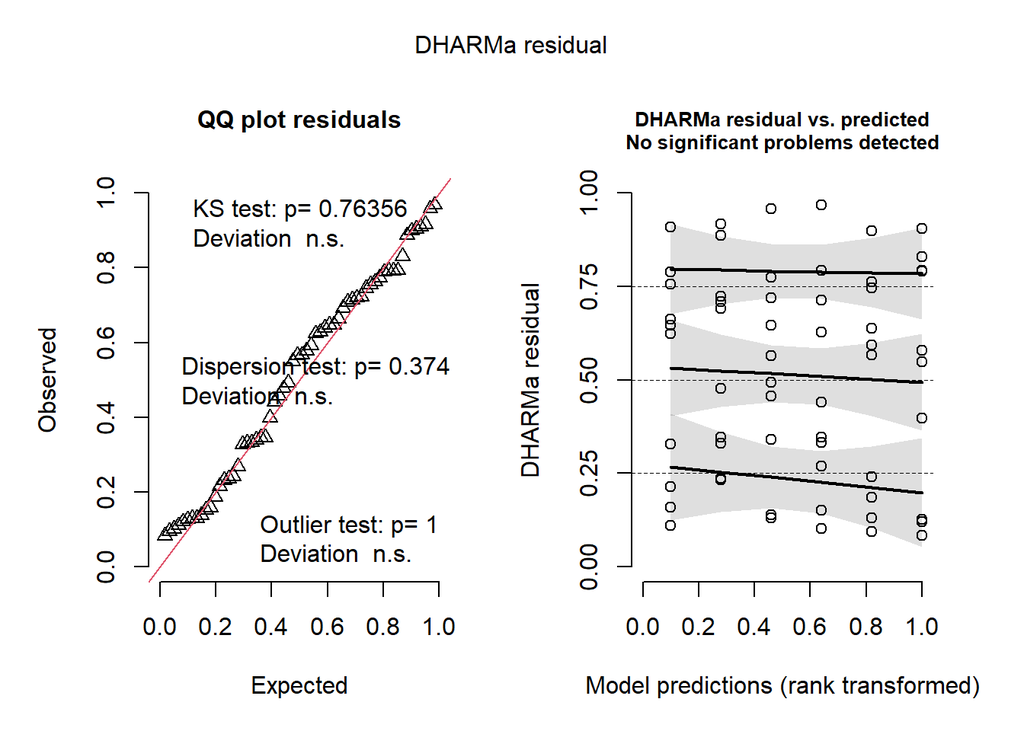

```r
res_nb <- simulateResiduals(m_nb_add, n = 1000)
plot(res_nb)
```

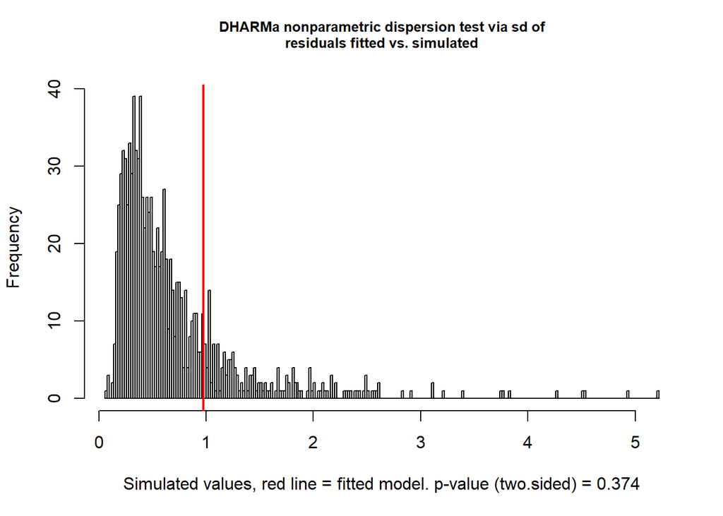

```
    DHARMa nonparametric dispersion test via sd of residuals fitted vs.
    simulated

data:  simulationOutput
dispersion = 1.4118, p-value = 0.374
alternative hypothesis: two.sided
```

```r
testDispersion(res_nb)
```

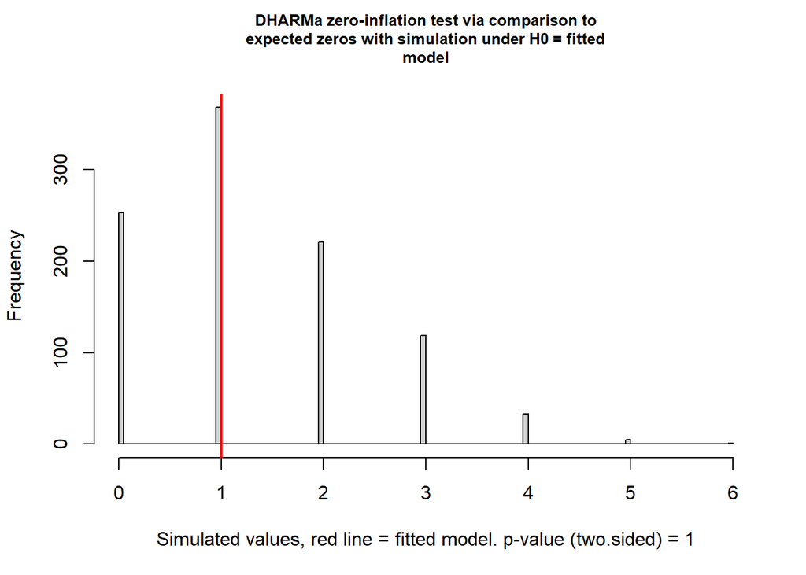

```
    DHARMa zero-inflation test via comparison to expected zeros with
    simulation under H0 = fitted model

data:  simulationOutput
ratioObsSim = 0.75188, p-value = 1
alternative hypothesis: two.sided
```

```r
testZeroInflation(res_nb)
```

No significant deviations detected, model is retained.

#### 2.3.1.5 Investigation of model estimates:

```r
Anova(m_nb_add)
```

```
Analysis of Deviance Table (Type II Wald chisquare tests)

Response: total_count
             Chisq Df Pr(>Chisq)
soil_type   0.5236  1     0.4693
layer     106.8516  2     <2e-16 ***
---
Signif. codes:  0 '***' 0.001 '**' 0.01 '*' 0.05 '.' 0.1 ' ' 1
```

```r
summary(m_nb_add)
```

```
 Family: nbinom2  ( log )
Formula:          total_count ~ soil_type + layer + (1 | monolith_ID)
Data: df_total

      AIC       BIC    logLik -2*log(L)  df.resid
    490.2     502.8    -239.1     478.2        54

Random effects:

Conditional model:
 Groups      Name        Variance Std.Dev.
 monolith_ID (Intercept) 0.4371   0.6612
Number of obs: 60, groups:  monolith_ID, 20

Dispersion parameter for nbinom2 family (): 2.65

Conditional model:
             Estimate Std. Error z value Pr(>|z|)
(Intercept)    2.2713     0.2807   8.093 5.83e-16 ***
soil_typedls  -0.2511     0.3470  -0.724    0.469
layer10        2.0044     0.2199   9.115  < 2e-16 ***
layer20        0.1827     0.2334   0.783    0.434
---
Signif. codes:  0 '***' 0.001 '**' 0.01 '*' 0.05 '.' 0.1 ' ' 1
```

Type II Wald chi-square tests revealed a highly significant effect of soil layer on total soil macrofauna abundance ($\chi^2$ = 106.85, df = 2, p < 0.001). The effect of soil type was not significant ($\chi^2$ = 0.52, df = 1, p = 0.469). Estimated random-effect variance (monolith) was 0.437 (SD = 0.661), indicating variation in baseline macrofauna abundance among monoliths.

#### 2.3.1.6 Pairwise testing for layers:

```r
# Estimated marginal means for layers (response scale)
emm_layers <- emmeans(m_nb_add, ~ layer, type = "response")

# Pairwise comparisons (Tukey correction)
pairwise_layers <- as.data.frame(
  pairs(emmeans(m_nb_add, ~ layer), adjust = "tukey")
)

# Back-transform estimates to abundance ratios
pairwise_layers$ratio <- exp(pairwise_layers$estimate)
pairwise_layers
```

```
 contrast   estimate        SE  df z.ratio p.value    ratio
 L - 10   -2.0043646 0.2198861 Inf  -9.115 <0.0001 0.134746
 L - 20   -0.1827018 0.2334295 Inf  -0.783  0.7137 0.833017
 10 - 20   1.8216628 0.2184400 Inf   8.339 <0.0001 6.182129

Results are averaged over the levels of: soil_type
Results are given on the log (not the response) scale.
P value adjustment: tukey method for comparing a family of 3 estimates
```

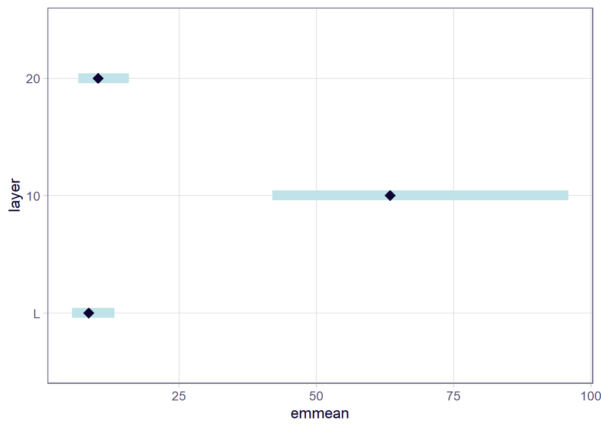

```r
# Plot estimated abundance on the response scale
plot(emm_layers)
```

Pairwise comparisons with Tukey adjustment shows that macrofauna abundance was significantly higher in layer 10 than in layers L (7.42 times) and 20 (6.18 times), while no significant difference was found between layers L and 20 (p = 0.714).

### 2.3.2 GLMM ecosystem engineers

#### 2.3.2.1 Formicidae (Ants)

```r
df_ants <- df_total %>%
  select(Formicidae, layer, monolith_ID, soil_type)

# M1: Poisson, additive effects
ants_p_add <- glmmTMB(
  Formicidae ~ soil_type + layer + (1 | monolith_ID),
  family = poisson(link = "log"),
  data = df_ants
)

# M2: Poisson, interaction
ants_p_int <- glmmTMB(
  Formicidae ~ soil_type * layer + (1 | monolith_ID),
  family = poisson(link = "log"),
  data = df_ants
)

# M3: Negative binomial, additive effects
ants_nb_add <- glmmTMB(
  Formicidae ~ soil_type + layer + (1 | monolith_ID),
  family = nbinom2(link = "log"),
  data = df_ants
)

# M4: Negative binomial, interaction
ants_nb_int <- glmmTMB(
  Formicidae~ soil_type * layer + (1 | monolith_ID),
  family = nbinom2(link = "log"),
  data = df_ants
)

AIC_ants <- AIC(ants_p_add, ants_p_int, ants_nb_add,ants_nb_int)

AIC_ants$delta_AIC <- AIC_ants$AIC - min(AIC_ants$AIC)

AIC_ants[order(AIC_ants$AIC), ]
```

```
            df      AIC delta_AIC
ants_nb_add  6 403.2416    0.0000
ants_nb_int  8 407.0212    3.7796
ants_p_int   7 544.2341  140.9925
ants_p_add   5 564.8352  161.5936
```

We keep the negative binomial distribution for the engineers because the AIC is lower that Poisson distribution models.

```r
anova(ants_nb_add, ants_nb_int) #likelihood ratio test LRT
```

```
Data: df_ants
Models:
ants_nb_add: Formicidae ~ soil_type + layer + (1 | monolith_ID), zi=~0, disp=~1
ants_nb_int: Formicidae ~ soil_type * layer + (1 | monolith_ID), zi=~0, disp=~1
            Df    AIC    BIC  logLik deviance  Chisq Chi Df Pr(>Chisq)
ants_nb_add  6 403.24 415.81 -195.62   391.24
ants_nb_int  8 407.02 423.78 -195.51   391.02 0.2204      2     0.8957
```

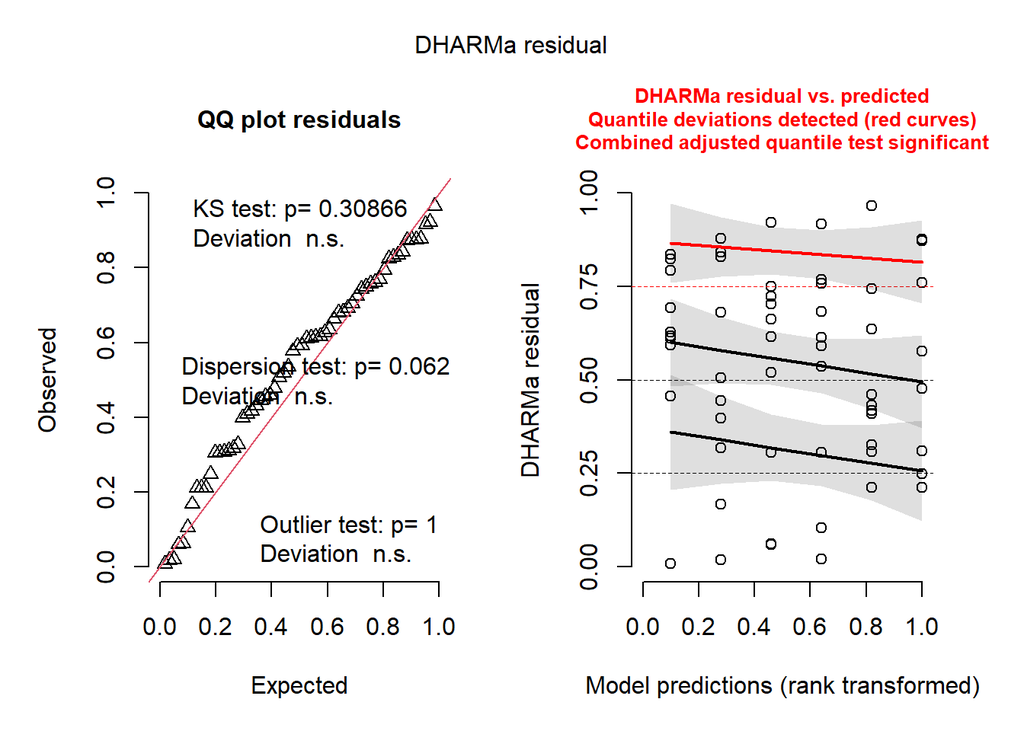

```r
res_nb_ants <- simulateResiduals(ants_nb_add, n = 1000)
plot(res_nb_ants)
```

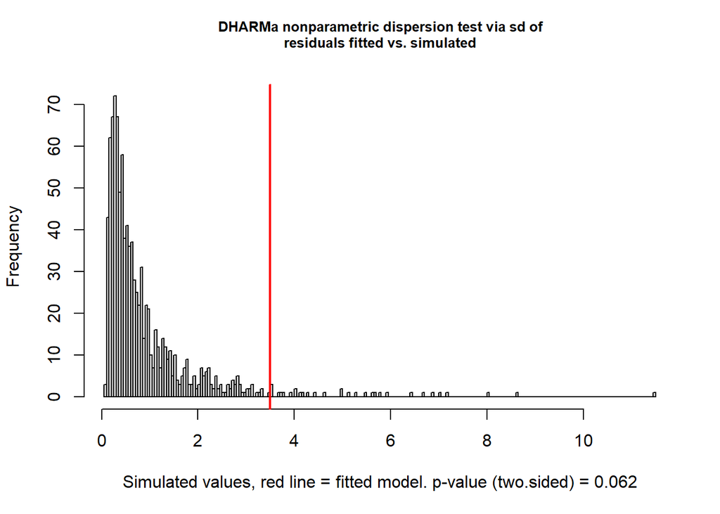

```
    DHARMa nonparametric dispersion test via sd of residuals fitted vs.
    simulated

data:  simulationOutput
dispersion = 3.8294, p-value = 0.062
alternative hypothesis: two.sided
```

```r
testDispersion(res_nb_ants)
```

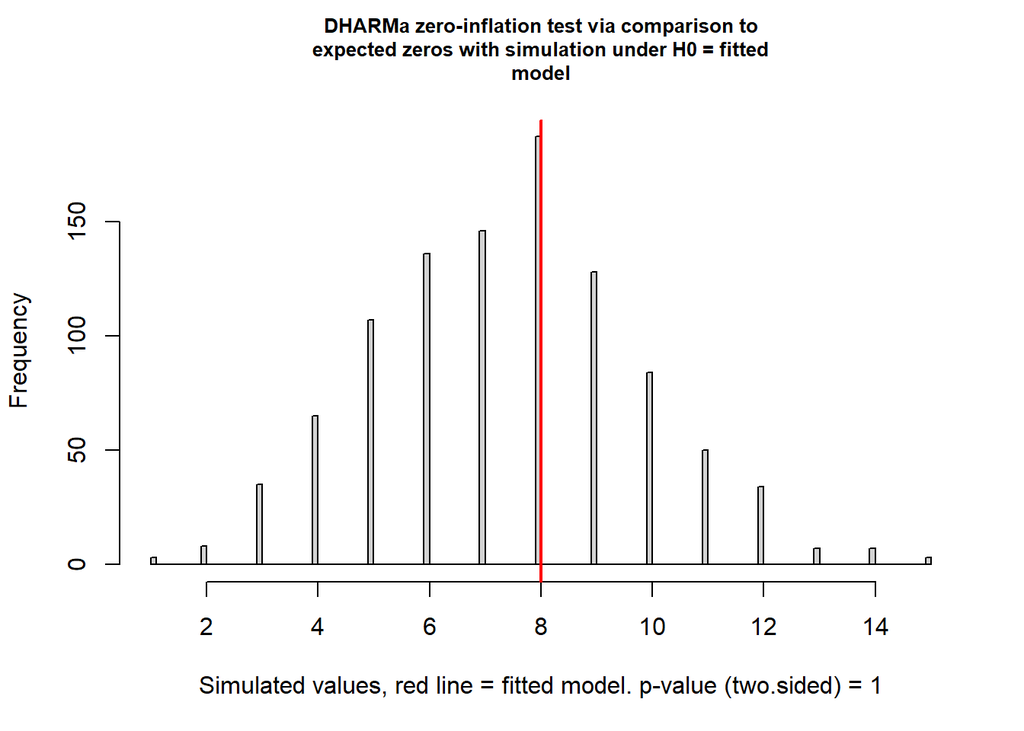

```
    DHARMa zero-inflation test via comparison to expected zeros with
    simulation under H0 = fitted model

data:  simulationOutput
ratioObsSim = 1.0757, p-value = 1
alternative hypothesis: two.sided
```

```r
testZeroInflation(res_nb_ants)
```

Quantile deviation detected (upper quantile specifically). Some relatively high-abundance observations may not be adequately captured by the model. Since all the other tests do not show any significant issues, ants_nb_add is retained as best-supported model regardless, though unexplained structure might remain.

```r
Anova(ants_nb_add)
```

```
Analysis of Deviance Table (Type II Wald chisquare tests)

Response: Formicidae
            Chisq Df Pr(>Chisq)
soil_type  0.4846  1     0.4863
layer     27.9984  2  8.322e-07 ***
---
Signif. codes:  0 '***' 0.001 '**' 0.01 '*' 0.05 '.' 0.1 ' ' 1
```

```r
summary(ants_nb_add)
```

```
 Family: nbinom2  ( log )
Formula:          Formicidae ~ soil_type + layer + (1 | monolith_ID)
Data: df_ants

      AIC       BIC    logLik -2*log(L)  df.resid
    403.2     415.8    -195.6     391.2        54

Random effects:

Conditional model:
 Groups      Name        Variance Std.Dev.
 monolith_ID (Intercept) 0.6553   0.8095
Number of obs: 60, groups:  monolith_ID, 20

Dispersion parameter for nbinom2 family (): 1.37

Conditional model:
             Estimate Std. Error z value Pr(>|z|)
(Intercept)    1.1385     0.3773   3.017  0.00255 **
soil_typedls   0.3119     0.4480   0.696  0.48633
layer10        1.6183     0.3261   4.962 6.96e-07 ***
layer20        0.4338     0.3357   1.292  0.19625
---
Signif. codes:  0 '***' 0.001 '**' 0.01 '*' 0.05 '.' 0.1 ' ' 1
```

```r
# Estimated marginal means for layers (response scale)
emm_layers_ants <- emmeans(ants_nb_add, ~ layer, type = "response")

# Pairwise comparisons (Tukey correction)
pairwise_layers_ants <- as.data.frame(
  pairs(emmeans(ants_nb_add, ~ layer), adjust = "tukey")
)

# Back-transform estimates to abundance ratios
pairwise_layers_ants$ratio <- exp(pairwise_layers_ants$estimate)
pairwise_layers_ants
```

```
 contrast   estimate        SE  df z.ratio p.value    ratio
 L - 10   -1.6182633 0.3261052 Inf  -4.962 <0.0001 0.198243
 L - 20   -0.4337734 0.3356551 Inf  -1.292  0.3995 0.648059
 10 - 20   1.1844898 0.3085176 Inf   3.839  0.0004 3.269019

Results are averaged over the levels of: soil_type
Results are given on the log (not the response) scale.
P value adjustment: tukey method for comparing a family of 3 estimates
```

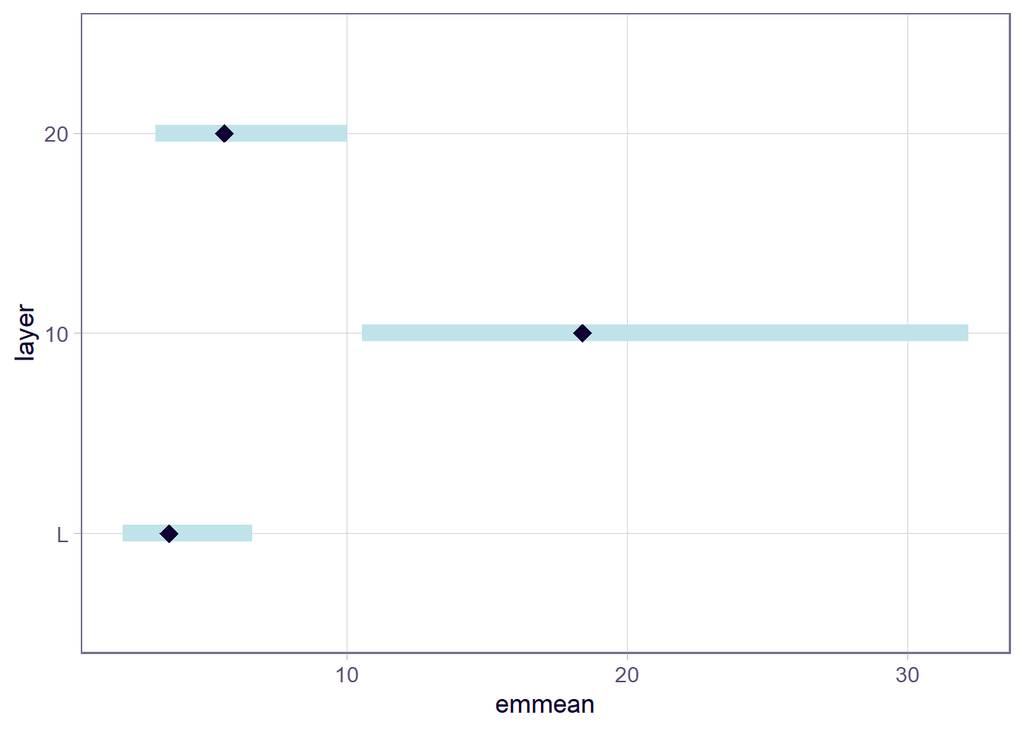

```r
# Plot estimated abundance on the response scale
plot(emm_layers_ants)
```

Type II Wald chi-square tests revealed a highly significant effect of soil layer on ant abundance ($\chi^2$ = 28.00, df = 2, p < 0.001). The effect of soil type was not significant ($\chi^2$ = 0.48, df = 1, p = 0.486). The estimated random-effect variance for monolith was 0.655 (SD = 0.810), indicating variation in baseline ant abundance among monoliths.

Pairwise comparisons with Tukey adjustment showed that ant abundance was significantly higher in layer 10 than in layer L (5.05 times) and layer 20 (3.27 times), while no significant difference was found between layers L and 20 (p = 0.3995).

#### 2.3.2.2 Isoptera (Termites)

```r
df_termites <- df_total %>%
  select(Isoptera, layer, monolith_ID, soil_type)


# M1: Poisson, additive effects
termites_p_add <- glmmTMB(
  Isoptera ~ soil_type + layer + (1 | monolith_ID),
  family = poisson(link = "log"),
  data = df_termites
)

# M2: Poisson, interaction
termites_p_int <- glmmTMB(
  Isoptera ~ soil_type * layer + (1 | monolith_ID),
  family = poisson(link = "log"),
  data = df_termites
)

# M3: Negative binomial, additive effects
termites_nb_add <- glmmTMB(
  Isoptera ~ soil_type + layer + (1 | monolith_ID),
  family = nbinom2(link = "log"),
  data = df_termites
)

# M4: Negative binomial, interaction
termites_nb_int <- glmmTMB(
  Isoptera~ soil_type * layer + (1 | monolith_ID),
  family = nbinom2(link = "log"),
  data = df_termites
)

AIC_termites <- AIC(termites_p_add, termites_p_int,
                    termites_nb_add,termites_nb_int)

AIC_termites$delta_AIC <- AIC_termites$AIC - min(AIC_termites$AIC)

AIC_termites[order(AIC_termites$AIC), ]
```

```
                df      AIC  delta_AIC
termites_nb_add  6 246.3315   0.000000
termites_nb_int  8 248.0288   1.697214
termites_p_int   7 342.7324  96.400833
termites_p_add   5 346.7858 100.454260
```

We keep the negative binomial distribution for the engineers because the AIC is lower that Poisson distribution models.

```r
anova(termites_nb_add, termites_nb_int) #likelihood ratio test LRT
```

```
Data: df_termites
Models:
termites_nb_add: Isoptera ~ soil_type + layer + (1 | monolith_ID), zi=~0, disp=~1
termites_nb_int: Isoptera ~ soil_type * layer + (1 | monolith_ID), zi=~0, disp=~1
                Df    AIC    BIC  logLik deviance  Chisq Chi Df Pr(>Chisq)
termites_nb_add  6 246.33 258.90 -117.17   234.33
termites_nb_int  8 248.03 264.78 -116.01   232.03 2.3028      2     0.3162
```

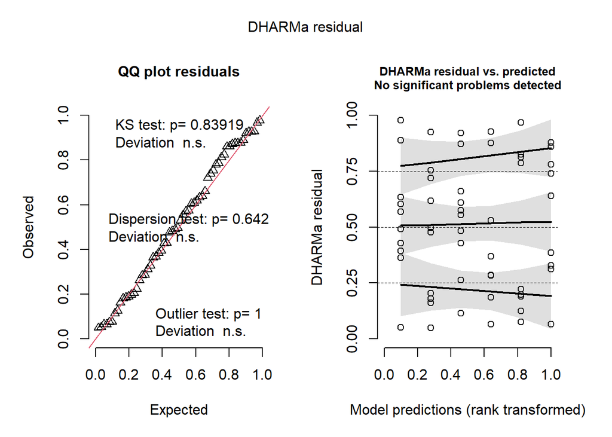

```r
res_nb_termites <- simulateResiduals(termites_nb_add, n = 1000)
plot(res_nb_termites)
```

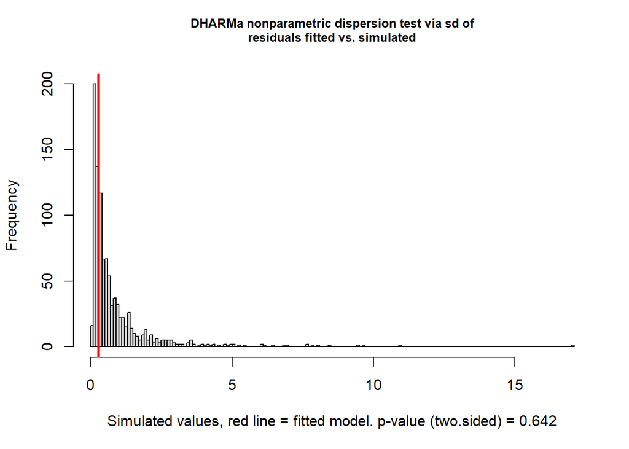

```
    DHARMa nonparametric dispersion test via sd of residuals fitted vs.
    simulated

data:  simulationOutput
dispersion = 0.31032, p-value = 0.642
alternative hypothesis: two.sided
```

```r
testDispersion(res_nb_termites)
```

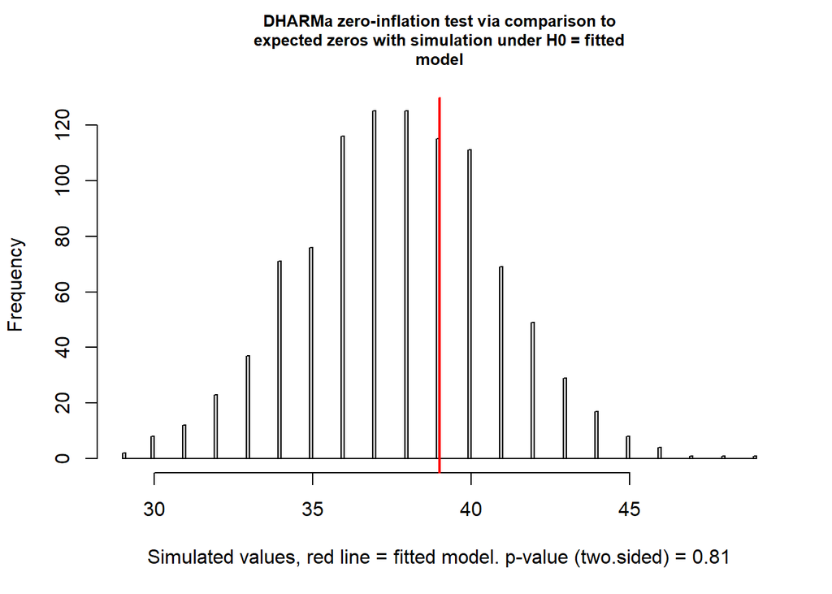

```
    DHARMa zero-inflation test via comparison to expected zeros with
    simulation under H0 = fitted model

data:  simulationOutput
ratioObsSim = 1.0332, p-value = 0.81
alternative hypothesis: two.sided
```

```r
testZeroInflation(res_nb_termites)
```

termites_nb_add is retained since adding the interaction does not significantly improve model fit and DHARMa model diagnostics are valid.

```r
Anova(termites_nb_add)
```

```
Analysis of Deviance Table (Type II Wald chisquare tests)

Response: Isoptera
            Chisq Df Pr(>Chisq)
soil_type  0.8857  1     0.3466
layer     36.5606  2  1.151e-08 ***
---
Signif. codes:  0 '***' 0.001 '**' 0.01 '*' 0.05 '.' 0.1 ' ' 1
```

```r
summary(termites_nb_add)
```

```
 Family: nbinom2  ( log )
Formula:          Isoptera ~ soil_type + layer + (1 | monolith_ID)
Data: df_termites

      AIC       BIC    logLik -2*log(L)  df.resid
    246.3     258.9    -117.2     234.3        54

Random effects:

Conditional model:
 Groups      Name        Variance  Std.Dev.
 monolith_ID (Intercept) 8.222e-09 9.067e-05
Number of obs: 60, groups:  monolith_ID, 20

Dispersion parameter for nbinom2 family (): 0.214

Conditional model:
             Estimate Std. Error z value Pr(>|z|)
(Intercept)    1.0764     0.5551   1.939  0.05248 .
soil_typedls  -0.6465     0.6869  -0.941  0.34664
layer10        2.8949     0.7130   4.060 4.91e-05 ***
layer20       -3.7192     1.2338  -3.015  0.00257 **
---
Signif. codes:  0 '***' 0.001 '**' 0.01 '*' 0.05 '.' 0.1 ' ' 1
```

```r
# Estimated marginal means for layers (response scale)
emm_layers_termites <- emmeans(termites_nb_add, ~ layer, type = "response")

# Pairwise comparisons (Tukey correction)
pairwise_layers_termites <- as.data.frame(
  pairs(emmeans(termites_nb_add, ~ layer), adjust = "tukey")
)

# Back-transform estimates to abundance ratios
pairwise_layers_termites$ratio <- exp(pairwise_layers_termites$estimate)
pairwise_layers_termites
```

```
 contrast  estimate        SE  df z.ratio p.value    ratio
 L - 10   -2.894851 0.7130041 Inf  -4.060  0.0001   0.0553
 L - 20    3.719172 1.2337560 Inf   3.015  0.0073  41.2302
 10 - 20   6.614023 1.2203861 Inf   5.420 <0.0001 745.4761

Results are averaged over the levels of: soil_type
Results are given on the log (not the response) scale.
P value adjustment: tukey method for comparing a family of 3 estimates
```

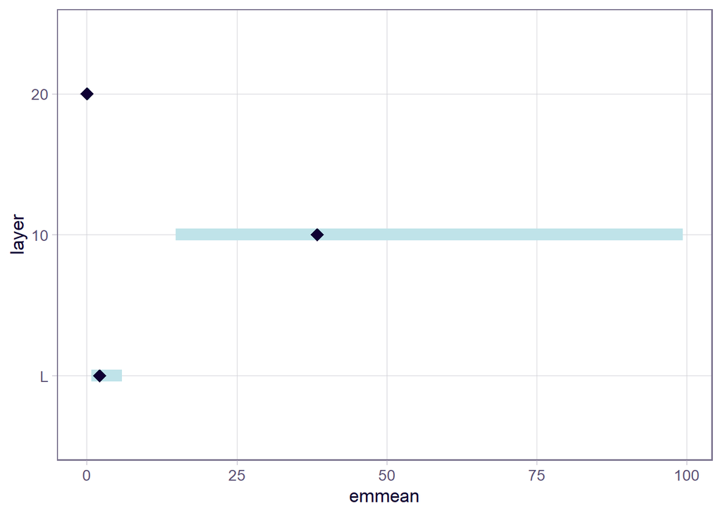

```r
# Plot estimated abundance on the response scale
plot(emm_layers_termites)
```

Type II Wald chi-square tests revealed a highly significant effect of soil layer on termite abundance ($\chi^2$ = 36.56, df = 2, p < 0.001). The effect of soil type was not significant ($\chi^2$ = 0.89, df = 1, p = 0.347). The estimated random-effect variance for monolith was effectively zero (8.22 × 10⁻⁹; SD = 0.00009), indicating virtually no remaining variation in baseline termite abundance among monoliths after accounting for the fixed effects.

#### 2.3.2.3 Lumbricina oligochaetes (Earthworms)

```r
df_earthworms <- df_total %>%
  select(Lumbricina_oligochaetes, layer, monolith_ID, soil_type)


# M1: Poisson, additive effects
earthworms_p_add <- glmmTMB(
  Lumbricina_oligochaetes ~ soil_type + layer + (1 | monolith_ID),
  family = poisson(link = "log"),
  data = df_earthworms
)

# M2: Poisson, interaction
earthworms_p_int <- glmmTMB(
  Lumbricina_oligochaetes ~ soil_type * layer + (1 | monolith_ID),
  family = poisson(link = "log"),
  data = df_earthworms
)

# M3: Negative binomial, additive effects
earthworms_nb_add <- glmmTMB(
  Lumbricina_oligochaetes ~ soil_type + layer + (1 | monolith_ID),
  family = nbinom2(link = "log"),
  data = df_earthworms
)

# M4: Negative binomial, interaction
earthworms_nb_int <- glmmTMB(
  Lumbricina_oligochaetes~ soil_type * layer + (1 | monolith_ID),
  family = nbinom2(link = "log"),
  data = df_earthworms
)

AIC_earthworms <- AIC(earthworms_p_add, earthworms_p_int,
                      earthworms_nb_add,earthworms_nb_int)

AIC_earthworms$delta_AIC <- AIC_earthworms$AIC - min(AIC_earthworms$AIC)

AIC_earthworms[order(AIC_earthworms$AIC), ]
```

```
                  df      AIC delta_AIC
earthworms_p_add   5 162.0840 0.0000000
earthworms_nb_add  6 162.7986 0.7145917
earthworms_p_int   7 163.7951 1.7111660
earthworms_nb_int  8 165.1570 3.0729812
```

```r
anova(earthworms_nb_add, earthworms_nb_int) #likelihood ratio test LRT
```

```
Data: df_earthworms
Models:
earthworms_nb_add: Lumbricina_oligochaetes ~ soil_type + layer + (1 | monolith_ID), zi=~0, disp=~1
earthworms_nb_int: Lumbricina_oligochaetes ~ soil_type * layer + (1 | monolith_ID), zi=~0, disp=~1
                  Df    AIC    BIC  logLik deviance  Chisq Chi Df Pr(>Chisq)
earthworms_nb_add  6 162.80 175.37 -75.399   150.80
earthworms_nb_int  8 165.16 181.91 -74.578   149.16 1.6416      2     0.4401
```

```r
anova(earthworms_p_add, earthworms_p_int) #likelihood ratio test LRT
```

```
Data: df_earthworms
Models:
earthworms_p_add: Lumbricina_oligochaetes ~ soil_type + layer + (1 | monolith_ID), zi=~0, disp=~1
earthworms_p_int: Lumbricina_oligochaetes ~ soil_type * layer + (1 | monolith_ID), zi=~0, disp=~1
                 Df    AIC    BIC  logLik deviance  Chisq Chi Df Pr(>Chisq)
earthworms_p_add  5 162.08 172.56 -76.042   152.08
earthworms_p_int  7 163.79 178.46 -74.898   149.79 2.2888      2     0.3184
```

AIC is very similar between all models, though models without interaction have lowest AIC. LRT shows no significant effect of adding the interaction. The two additive models are provisionally retained.

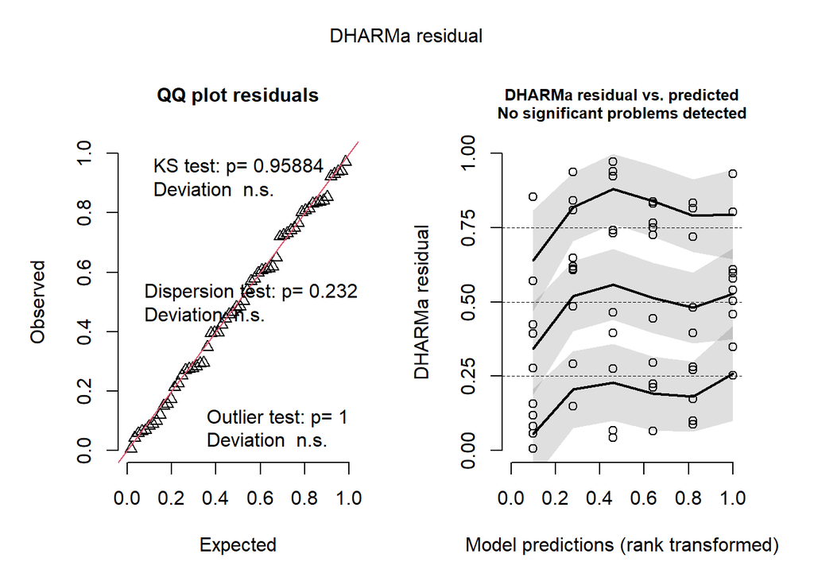

```r
res_p_earthworms <- simulateResiduals(earthworms_p_add, n = 1000)
plot(res_p_earthworms)
```

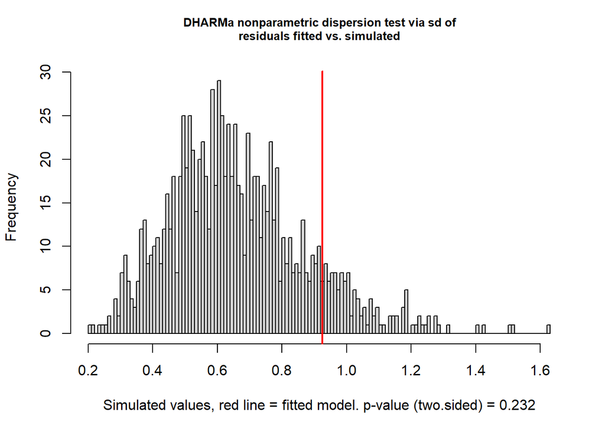

```
    DHARMa nonparametric dispersion test via sd of residuals fitted vs.
    simulated

data:  simulationOutput
dispersion = 1.4005, p-value = 0.232
alternative hypothesis: two.sided
```

```r
testDispersion(res_p_earthworms)
```

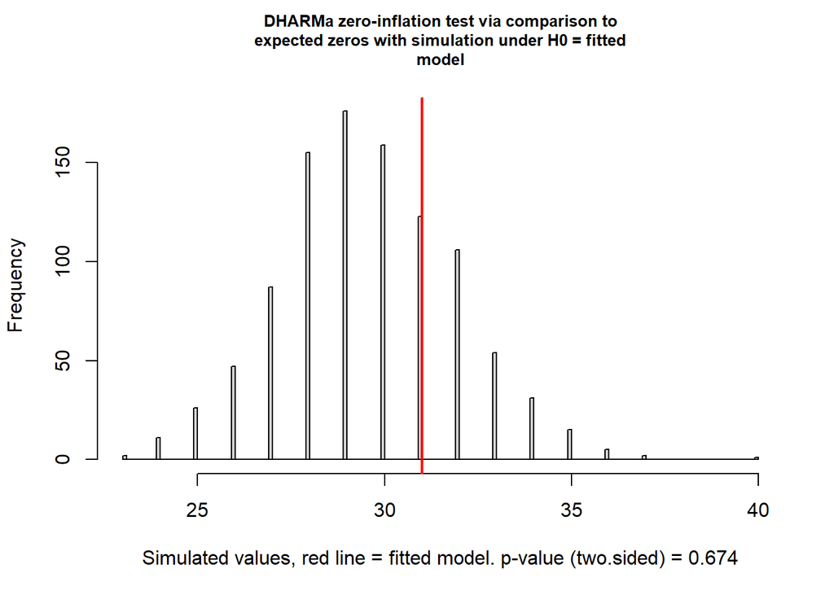

```
    DHARMa zero-inflation test via comparison to expected zeros with
    simulation under H0 = fitted model

data:  simulationOutput
ratioObsSim = 1.0471, p-value = 0.674
alternative hypothesis: two.sided
```

```r
testZeroInflation(res_p_earthworms)
```

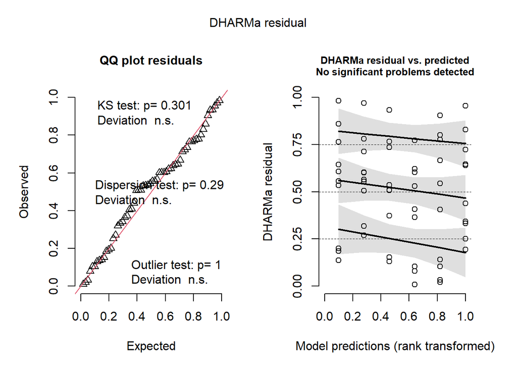

```r
res_nb_earthworms <- simulateResiduals(earthworms_nb_add, n = 1000)
plot(res_nb_earthworms)
```

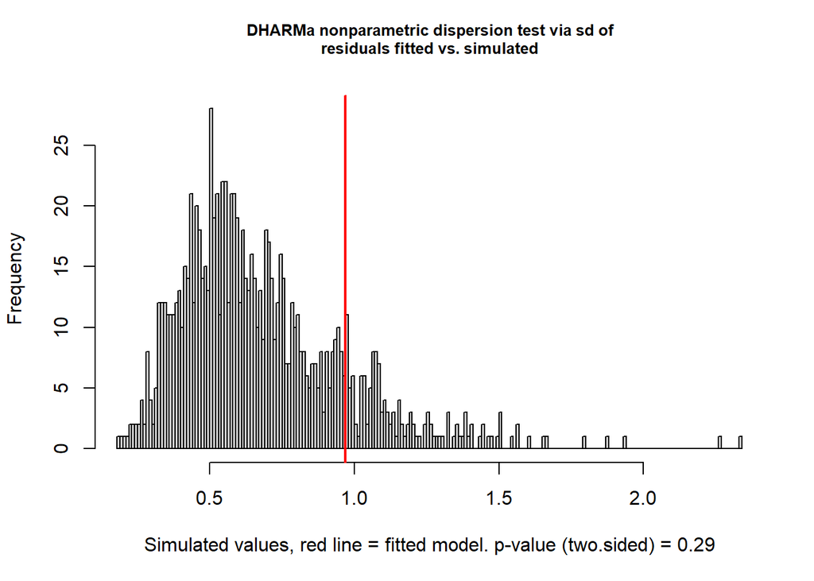

```
    DHARMa nonparametric dispersion test via sd of residuals fitted vs.
    simulated

data:  simulationOutput
dispersion = 1.4305, p-value = 0.29
alternative hypothesis: two.sided
```

```r
testDispersion(res_nb_earthworms)
```

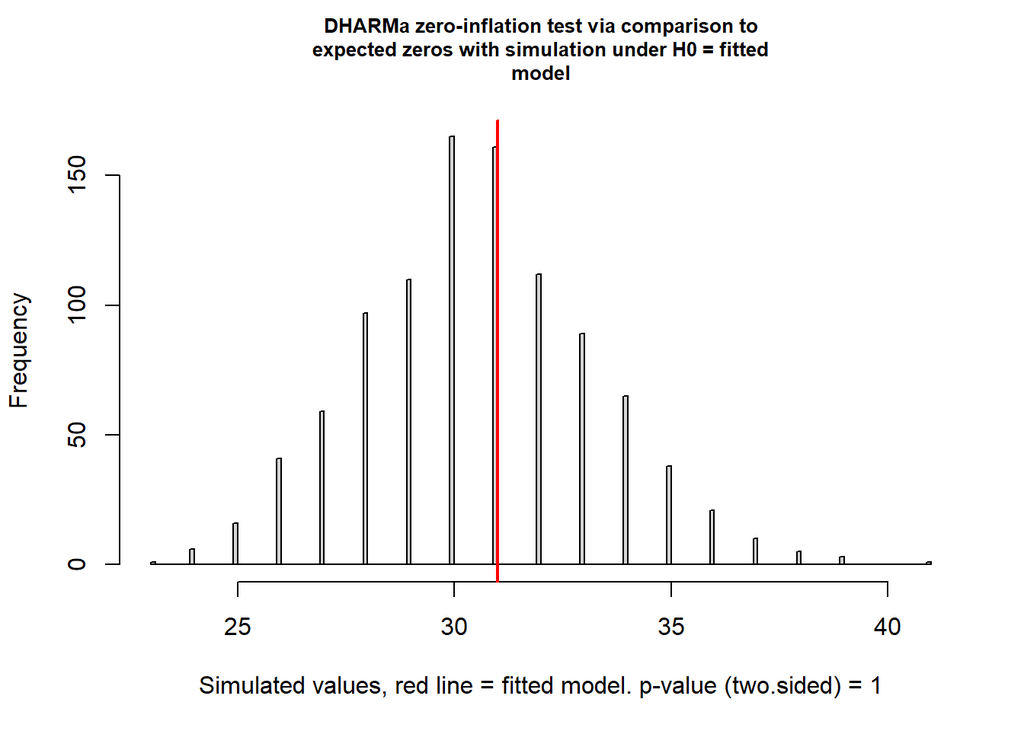

```
    DHARMa zero-inflation test via comparison to expected zeros with
    simulation under H0 = fitted model

data:  simulationOutput
ratioObsSim = 1.0128, p-value = 1
alternative hypothesis: two.sided
```

```r
testZeroInflation(res_nb_earthworms)
```

Both Poisson and negative binomial models do not show any significant issues in DHARMa residuals, dispersion test and zero inflation test. The Poisson model is retained because it has a slightly lower AIC and a more parsimonious structure (df lost 5, vs 6 in negative binomial).

```r
Anova(earthworms_p_add)
```

```
Analysis of Deviance Table (Type II Wald chisquare tests)

Response: Lumbricina_oligochaetes
            Chisq Df Pr(>Chisq)
soil_type  0.3451  1    0.55692
layer     12.6852  2    0.00176 **
---
Signif. codes:  0 '***' 0.001 '**' 0.01 '*' 0.05 '.' 0.1 ' ' 1
```

```r
summary(earthworms_p_add)
```

```
 Family: poisson  ( log )
Formula:
Lumbricina_oligochaetes ~ soil_type + layer + (1 | monolith_ID)
Data: df_earthworms

      AIC       BIC    logLik -2*log(L)  df.resid
    162.1     172.6     -76.0     152.1        55

Random effects:

Conditional model:
 Groups      Name        Variance Std.Dev.
 monolith_ID (Intercept) 0.5096   0.7138
Number of obs: 60, groups:  monolith_ID, 20

Conditional model:
               Estimate Std. Error z value Pr(>|z|)
(Intercept)    -21.8844 10511.2726  -0.002    0.998
soil_typedls     0.2372     0.4038   0.587    0.557
layer10         22.6146 10511.2722   0.002    0.998
layer20         21.7783 10511.2720   0.002    0.998
```

```r
# Estimated marginal means for layers (response scale)
emm_layers_earthworms <- emmeans(earthworms_p_add, ~ layer, type = "response")
emm_layers_earthworms
```

```
 layer rate       SE  df asymp.LCL asymp.UCL
 L     0.00 3.70e-06 Inf     0.000       Inf
 10    2.34 5.30e-01 Inf     1.499         4
 20    1.01 2.74e-01 Inf     0.596         2

Results are averaged over the levels of: soil_type
Confidence level used: 0.95
Intervals are back-transformed from the log scale
```

```r
# Pairwise comparisons (Tukey correction)
pairwise_layers_earthworms <- as.data.frame(
  pairs(emmeans(earthworms_p_add, ~ layer), adjust = "tukey")
)

# Back-transform estimates to abundance ratios
pairwise_layers_earthworms$ratio <- exp(pairwise_layers_earthworms$estimate)
pairwise_layers_earthworms
```

```
 contrast   estimate        SE  df z.ratio p.value    ratio
 L - 10   -22.614594 10511.272 Inf  -0.002  1.0000 0.000000
 L - 20   -21.778346 10511.272 Inf  -0.002  1.0000 0.000000
 10 - 20    0.836248     0.235 Inf   3.562  0.0011 2.307692

Results are averaged over the levels of: soil_type
Results are given on the log (not the response) scale.
P value adjustment: tukey method for comparing a family of 3 estimates
```

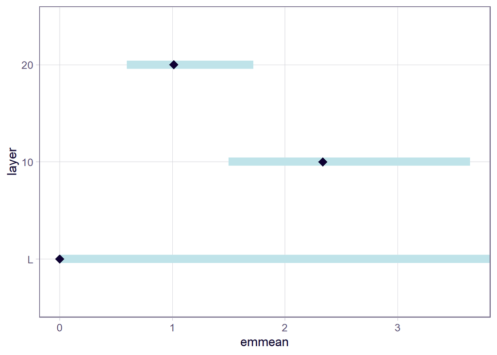

```r
# Plot estimated abundance on the response scale
plot(emm_layers_earthworms)
```

Type II Wald chi-square tests revealed a significant effect of soil layer on earthworm abundance ($\chi^2$ = 12.69, df = 2, p = 0.0018). The effect of soil type was not significant ($\chi^2$ = 0.35, df = 1, p = 0.557). The estimated random-effect variance for monolith was 0.510 (SD = 0.714), indicating variation in baseline earthworm abundance among monoliths. The model summary shows that estimates including layer were highly instable, with standard errors of around 10511. Coefficients can therefore not be correctly interpreted for layers.

Pairwise comparisons with Tukey adjustment showed significantly higher abundance in layer 10 than in layer 20 (2.31 times). No significant differences were detected between layer L and either layer 10 or layer 20 (both p = 1.000). However, the estimated abundance of earthworms in layer L was zero with an unbounded confidence interval. No earthworms were observed in layer L during the sampling, which explains the high errors in the models and the unbounded confidence interval.

## 2.4 PERMANOVA

### 2.4.1 Data preparation

```r
df_perm <- df
# defining taxonomic abundance columns
community_cols <- names(df_perm)[7:ncol(df_perm)]

# remove zero-abundance samples (decision following vegan
#handbook, since zero-abundance layer does not convey community
#composition information)
keep <- rowSums(df_perm[, community_cols], na.rm = TRUE) > 0
df_perm <- df_perm[keep, , drop = FALSE]

# create the community matrix
comm <- as.matrix(df_perm[, community_cols])
storage.mode(comm) <- "numeric" # making sure its num

# define meta_layer for tested variables + monoliths
meta_layer <- df_perm[, c("monolith_ID", "soil_type", "layer")]

# create Bray-Curtis dissimilarity matrix
dist_layer <- vegdist(comm, method = "bray")
```

### 2.4.2 PERMANOVA layer effects

```r
# Bray-Curtis PERMANOVA
# define permutation scheme, limit WITHIN monoliths (due to
#spatial dependence of the three layers)
perm_layer <- how(
  nperm = 9999,
  blocks = meta_layer$monolith_ID
) # chose large number of perms for stabilizing p value, increase
#for borderline p values

# run based on defined scheme
permanova_layer <- adonis2(
  dist_layer ~ layer,
  data = meta_layer,
  permutations = perm_layer
)

print(permanova_layer)
```

```
Permutation test for adonis under reduced model
Blocks:  meta_layer$monolith_ID
Permutation: free
Number of permutations: 9999

adonis2(formula = dist_layer ~ layer, data = meta_layer, permutations = perm_layer)
         Df SumOfSqs      R2      F Pr(>F)
Model     2   2.9211 0.16314 5.4584  1e-04 ***
Residual 56  14.9845 0.83686
Total    58  17.9056 1.00000
---
Signif. codes:  0 '***' 0.001 '**' 0.01 '*' 0.05 '.' 0.1 ' ' 1
```

```r
# => significant, R2 16%
```

PERMANOVA shows a significant effect of soil layer on macrofauna community composition (Bray–Curtis dissimilarity: F = 5.46, R² = 0.163, p = 0.0001). Soil layer explained around 16.3% of variation in the community composition, indicating that macrofauna community composition differed significantly among layers.

```r
# check dispersion using betadisper (if significant, permanova
#result might only be due to unequal dispersion; a bit like
#homogeneity of variance in anova) / is like non-parametric
#Levene test

bd_layer <- betadisper(
  dist_layer,
  group = meta_layer$layer,
  type = "median",
  bias.adjust = TRUE
)

# same permutation scheme

dispersion_layer <- permutest(
  bd_layer,
  permutations = perm_layer
)

print(dispersion_layer)
```

```
Permutation test for homogeneity of multivariate dispersions
Blocks:  meta_layer$monolith_ID
Permutation: free
Number of permutations: 9999

Response: Distances
          Df  Sum Sq  Mean Sq      F N.Perm Pr(>F)
Groups     2 0.03176 0.015882 0.7465   9999 0.3209
Residuals 56 1.19141 0.021275
```

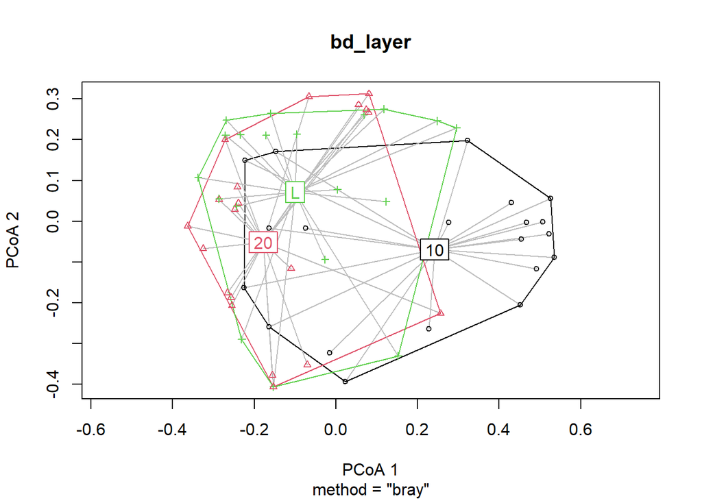

```r
# quick visualisation (PCoA)
plot(bd_layer)
```

Homogeneity of multivariate dispersion was assessed using a permutation test based on betadisper. No significant differences in dispersion were detected for soil layers (F = 0.75, p = 0.321), suggesting that the PERMANOVA result was not driven by differences in within-group dispersion.

```r
# pairwise PERMANOVA testing for layers
layer_pairs <- list(
  c("L", "10"),
  c("L", "20"),
  c("10", "20")
)

# function based to apply to all pairs
pairwise_results <- lapply(layer_pairs, function(pair) {

  # Keep only the two layers being compared
  keep_pair <- meta_layer$layer %in% pair

  meta_pair <- droplevels(meta_layer[keep_pair, , drop = FALSE])

  # subset the original Bray-Curtis distance object for this pair
  dist_pair <- as.dist(as.matrix(dist_layer)[keep_pair, keep_pair])

  # restrict perms to monoliths, like in global PERMANOVA
  perm_pair <- how(
    nperm = 9999,
    blocks = meta_pair$monolith_ID
  )

  # perform PERMANOVA
  res <- adonis2(
    dist_pair ~ layer,
    data = meta_pair,
    permutations = perm_pair
  )

  #for nice table notation
  data.frame(
    comparison = paste(pair, collapse = " vs "),
    F = res$F[1],
    R2 = res$R2[1],
    p_value = res$`Pr(>F)`[1]
  )
})

pairwise_results <- do.call(rbind, pairwise_results)

# Correct for the three pairwise tests
pairwise_results$p_adjusted <- p.adjust(
  pairwise_results$p_value,
  method = "bonferroni" ) # Bonferroni correction

print(pairwise_results)
```

```
  comparison        F        R2 p_value p_adjusted
1    L vs 10 6.053937 0.1406129   2e-04      6e-04
2    L vs 20 4.553169 0.1095745   1e-04      3e-04
3   10 vs 20 5.755480 0.1315374   3e-04      9e-04
```

### 2.4.3 PCoA for layers

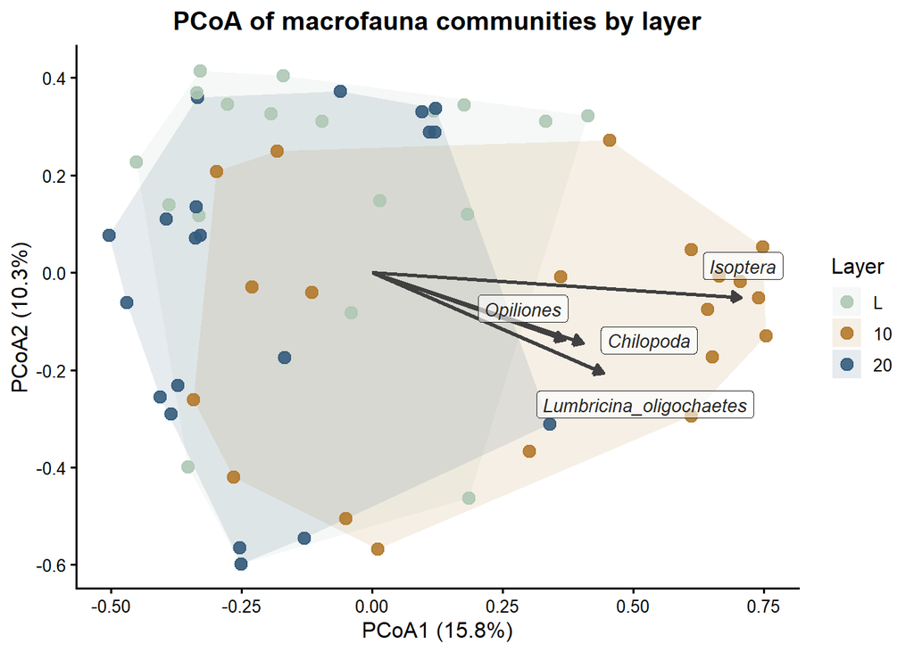

```r
# calculate, using same distance matrix like in PERMANOVA
pcoa_layer <- cmdscale(
  dist_layer, k = 2, eig = TRUE, add = TRUE
) # set k for number of dimensions +> k = 2 two dimensional

# sample scores
pcoa_df_perm <- data.frame(
  PCoA1 = pcoa_layer$points[, 1],
  PCoA2 = pcoa_layer$points[, 2],
  layer = factor(df_perm$layer, levels = c("L", "10", "20"))
)

# calculate hulls around samples
hull_df_perm <- pcoa_df_perm %>%
  group_by(layer) %>%
  slice(chull(PCoA1, PCoA2))

# fit taxon abundances to the PCoA (using same permutation scheme
#as in PERMANOVA)
fit <- envfit(
  pcoa_layer$points,
  comm,
  permutations = perm_layer
)

# extract taxon results and adjust p-values (multiple testing)
taxa_results <- data.frame(
  taxon = rownames(fit$vectors$arrows),
  R2 = fit$vectors$r,
  p_value = fit$vectors$pvals
)

taxa_results$p_adjusted <- p.adjust(
  taxa_results$p_value,
  method = "BH"
) # BH adjustment for multiple testing (false discovery rate)

# extract taxon vectors
vec <- as.data.frame(scores(fit, display = "vectors"))
vec$taxon <- rownames(vec)
names(vec)[1:2] <- c("PCoA1", "PCoA2")

# match adjusted p-values by taxon
vec$p_adjusted <- taxa_results$p_adjusted[
  match(vec$taxon, taxa_results$taxon)
]

# keep those with adjusted p < 0.05
vec <- vec[
  !is.na(vec$p_adjusted) &
    vec$p_adjusted < 0.05,
]

# calculate dim1 and dim2 percentages
eig <- pcoa_layer$eig
positive_eig <- eig[eig > 0]

pc1_pct <- 100 * eig[1] / sum(positive_eig)
pc2_pct <- 100 * eig[2] / sum(positive_eig)


# plot PCoA
p <- ggplot(pcoa_df_perm, aes(PCoA1, PCoA2, color = layer)) +
  geom_polygon(
    data = hull_df_perm,
    aes(x = PCoA1, y = PCoA2, fill = layer, group = layer),
    alpha = 0.12,
    color = NA,
    inherit.aes = FALSE
  ) +
  geom_point(size = 3, alpha = 0.9) +
  scale_color_manual(values = layer_colors) +
  scale_fill_manual(values = layer_colors) +
  theme_classic(base_size = 12) +
  labs(
    title = "PCoA of macrofauna communities by layer",
    color = "Layer",
    fill = "Layer",
    x = sprintf("PCoA1 (%.1f%%)", pc1_pct),
    y = sprintf("PCoA2 (%.1f%%)", pc2_pct)
  ) +
  theme(
    plot.title = element_text(face = "bold", hjust = 0.5),
    legend.position = "right"
  )


# taxon arrows and labels
  p <- p +
    geom_segment(
      data = vec,
      aes(
        x = 0, y = 0,
        xend = PCoA1, yend = PCoA2
      ),
      inherit.aes = FALSE,
      color = "grey25",
      linewidth = 0.9,
      arrow = arrow(
        length = unit(0.2, "cm"),
        type = "closed"
      )
    ) +
    geom_label_repel(
      data = vec,
      aes(
        x = PCoA1, y = PCoA2,
        label = taxon
      ),
      inherit.aes = FALSE,
      color = "grey15",
      fill = alpha("white", 0.6),
      label.size = NA,
      size = 3.5,
      fontface = "italic",
      box.padding = 0.6,
      point.padding = 0.5,
      force = 3,
      max.overlaps = Inf,
      min.segment.length = Inf,
      segment.color = NA,
      seed = 123
    )

print(p)
```

```r
taxa_results %>%
  filter(p_adjusted < 0.05) %>%
  arrange(p_adjusted)
```

```
                                          taxon        R2 p_value p_adjusted
Chilopoda                             Chilopoda 0.1834736  0.0001 0.00140000
Isoptera                               Isoptera 0.5009809  0.0001 0.00140000
Opiliones                             Opiliones 0.1545623  0.0011 0.01026667
Lumbricina_oligochaetes Lumbricina_oligochaetes 0.2383417  0.0022 0.01540000
```

The first two PCoA axes accounted for 26.1% of the variation in macrofauna community composition (PCoA1: 15.8%; PCoA2: 10.3%). The ordination showed partial separation of communities among soil layers. Samples from layers L and 20 exhibited substantial overlap, whereas samples from layer 10 were more distinctly shifted towards the right of the ordination.

The envfit analysis identified four taxa significantly associated with the ordination: Isoptera (R² = 0.501, adjusted p = 0.0014), Chilopoda (R² = 0.183, adjusted p = 0.0014), Opiliones (R² = 0.155, adjusted p = 0.0103) and Lumbricina_oligochaetes (R² = 0.238, adjusted p = 0.0154). Isoptera showed the strongest association with the ordination.

### 2.4.4 PERMANOVA for soil types

```r
# sum across all layers within each monolith => to test
#independent of layer effects, since dependent of monolith
comm_mono <- rowsum(
  comm,
  group = df_perm$monolith_ID,
  reorder = FALSE
)

# one metadata row per monolith
meta_mono <- df_perm[
  !duplicated(df_perm$monolith_ID),
  c("monolith_ID", "soil_type")
]

# aligning matrix with metadata
comm_mono <- comm_mono[
  as.character(meta_mono$monolith_ID),
  ,
  drop = FALSE
]
```

Is aggregated per monolith since layers are not independent. Only tests between soils on monolith level.

```r
dist_soil <- vegdist(comm_mono, method = "bray")
# Bray-Curtis PERMANOVA

permanova_soil <- adonis2(
  dist_soil ~ soil_type,
  data = meta_mono,
  permutations = 9999
)

print(permanova_soil)
```

```
Permutation test for adonis under reduced model
Permutation: free
Number of permutations: 9999

adonis2(formula = dist_soil ~ soil_type, data = meta_mono, permutations = 9999)
         Df SumOfSqs      R2      F Pr(>F)
Model     1   0.3557 0.08527 1.6778 0.1323
Residual 18   3.8162 0.91473
Total    19   4.1720 1.00000
```

```r
# not significant, no differences by soil type

# betadisper

bd_soil <- betadisper(
  dist_soil,
  group = meta_mono$soil_type,
  type = "median",
  bias.adjust = TRUE
)

dispersion_soil <- permutest(
  bd_soil,
  permutations = 9999
)

print(dispersion_soil)
```

```
Permutation test for homogeneity of multivariate dispersions
Permutation: free
Number of permutations: 9999

Response: Distances
          Df  Sum Sq   Mean Sq      F N.Perm Pr(>F)
Groups     1 0.00310 0.0031035 0.1135   9999 0.7332
Residuals 18 0.49227 0.0273482
```

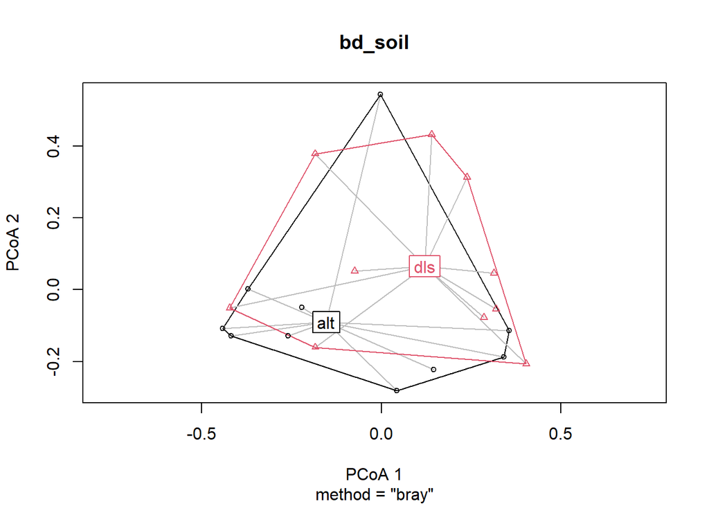

```r
# simple plot
plot(bd_soil)
```